# Лабораторная работа №2

Дисциплина: Основы информационной безопасности.

Лобанова П. И.

Российский университет дружбы народов, Москва, Россия

01 марта 2024

# Информация

## Докладчик

- Лобанова Полина Иннокентьевна
- Учащаяся на направлении “Компьютерные и информационные технологии”
- Студентка группы НКАбд-01-22
- polla-2004@mail.ru

# Цель

Получение практических навыков работы в консоли с атрибутами файлов, закрепление теоретических основ дискреционного разграничения доступа в современных системах с открытым кодом на базе ОС Linux.

# Ход работы

## .

В установленной при выполнении предыдущей лабораторной работы операционной системе создаем учётную запись пользователя guest.

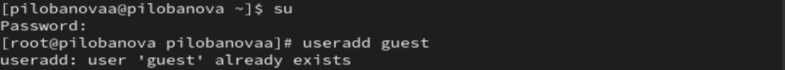

*Создание нового пользователя.*

## .

Задаем пароль для пользователя guest.

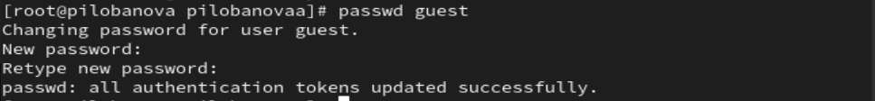

*Запись пароля.*

## .

Входим в систему от имени пользователя guest.

[figure not shown]

*Смена пользователя.*

## .

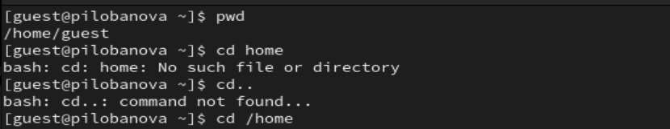

*Командой pwd.*

## .

Уточняем имя вашего пользователя командой whoami.

## .

Уточняем имя вашего пользователя, его группу, а также группы, куда входит пользователь, командой id. Сравниваем вывод id с выводом команды groups, они совпадают.

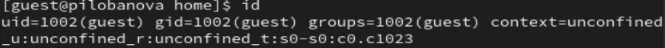

*Команда id.*

## .

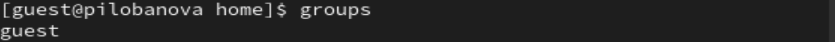

*Команда groups.*

## .

Сравниваем полученную информацию об имени пользователя с данными, выводимыми в приглашении командной строки. Они совпадают. Просмотрим файл /etc/passwd и сравним найденные данные с полученными в предыдущих пунктах. Они тоже совпадают.

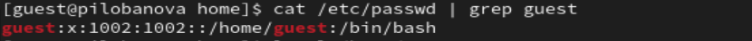

## .

Определим существующие в системе директории. Нам удалось ли вам получить список поддиректорий директории /home.

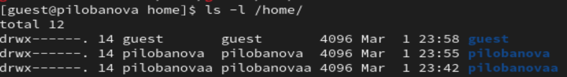

*Команда ls -l.*

## .

Проверим какие расширенные атрибуты установлены на поддиректориях, находящихся в директории /home.

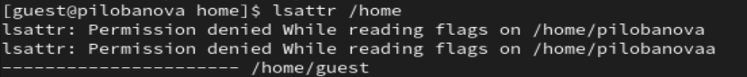

*Команда lsattr.*

## .

Создадим в домашней директории поддиректорию dir1. Определим командами ls -l и lsattr, какие права доступа и расширенные атрибуты были выставлены на директорию dir1.

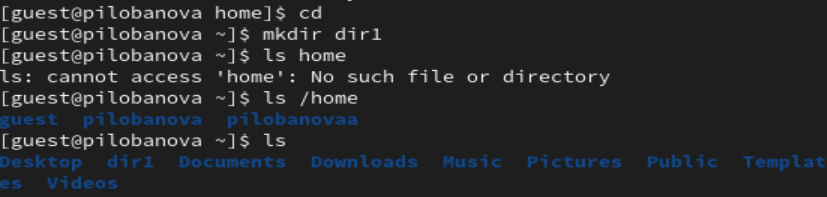

*Создание директории.*

## .

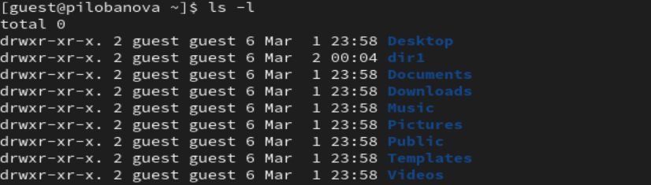

*Команда ls -l.*

## .

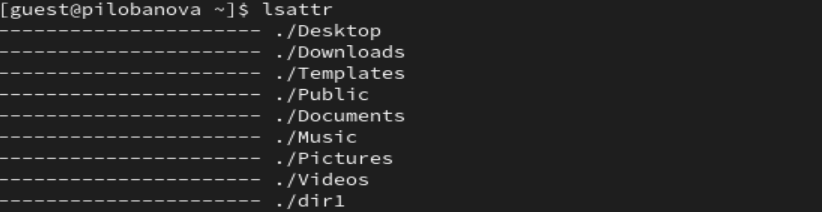

*Команда lsattr.*

## .

Снимем с директории dir1 все атрибуты и проверим с её помощью правильность выполнения команды ls -l.

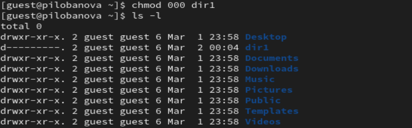

*Снятие прав.*

## .

Попытайтесь создать в директории dir1 файл file1. Поскольку мы только что сняли все права для всех пользователей, у нас не получилось это сделать. В сообщении об ошибке говориться, что нам отказано в доступе и файл не создался.

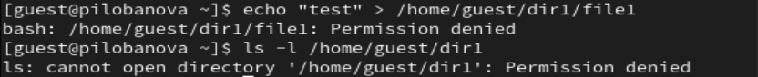

*Попытка создать файл.*

## .

Заполним таблицу «Установленные права и разрешённые действия», выполняя действия от имени владельца директории (файлов), определив опытным путём, какие операции разрешены, а какие нет. Если операция разрешена, занесите в таблицу знак «+», если не разрешена, знак «-».

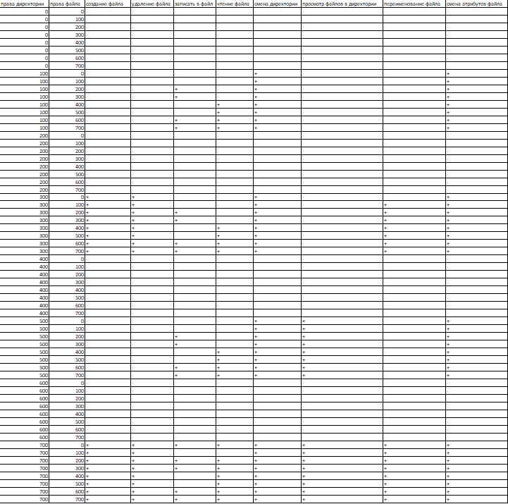

*«Установленные права и разрешённые действия».*

## .

На основании заполненной таблицы определим те или иные минимально необходимые права для выполнения операций внутри директории dir1, заполнив табл. 2.2.

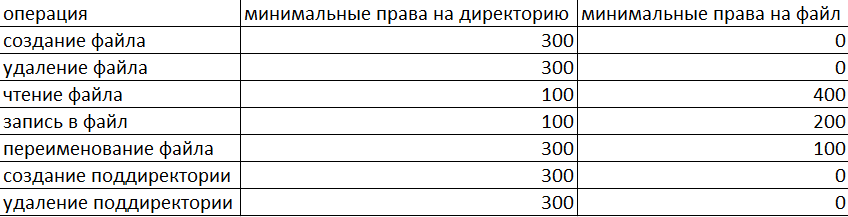

*«Минимально необходимые права для выполнения операций».*

# Вывод

Я получила практические навыки работы в консоли с атрибутами файлов.